# class07.Rmd

Arpit Danewalia

10/22/2019

```r
source("http://tinyurl.com/rescale-R")
```

```r
rescale( c(11,10,5,NA,6))
```

```
## [1] 1.0000000 0.8333333 0.0000000        NA 0.1666667
```

```r
#rescale2(c(1:10, "barry"))
```

```r
#rescale(c(1:10, "barry"))
```

##A new function called **is.na()** Write a function to find where there are NA elements in two input vectors First make some simple input where I know the answer

```r
x <- c(1,2,NA,3,NA)
y <- c(NA,3,NA,3,4)
```

Looked online and found **is.na()** function

```r
is.na(x)
```

```
## [1] FALSE FALSE  TRUE FALSE  TRUE
```

```r
is.na(y)
```

```
## [1]  TRUE FALSE  TRUE FALSE FALSE
```

and the **which()** function tells me where the TRUE values are

```r
which(is.na(x))
```

```
## [1] 3 5
```

```r
which(is.na(y))
```

```
## [1] 1 3
```

The AND function required two input TRUE to give a TRUE output

```r
is.na(x) & is.na(y)
```

```
## [1] FALSE FALSE  TRUE FALSE FALSE
```

Taking the **sum()** of TRUE FALSE vector will tell me how many TRUE elements I have

```r
sum(is.na(x) & is.na(y))
```

```
## [1] 1
```

This is a working snippet!!

```r
sum(c(TRUE,TRUE, FALSE, TRUE))
```

```
## [1] 3
```

Now turn it into a function

```r
both_na <- function (x,y) {
  sum(is.na(x) & is.na(y))
}
```

```r
both_na (x,y)
```

```
## [1] 1
```

```r
x <- c(NA, NA, NA)
y1 <- c( 1, NA, NA)
y2 <- c( 1, NA, NA, NA)
```

```r
both_na(x, y1)
```

```
## [1] 2
```

```r
both_na(x, y2)
```

```
## [1] 3
```

```r
x2 <- c(NA,NA)
both_na(x2,y2)
```

```
## [1] 3
```

Remember this function recyles the value to fit the greatest

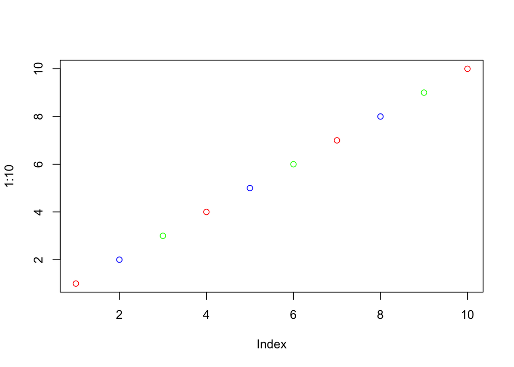

```r
plot(1:10, col=c("red","blue","green"))
```

```r
x <- c(1, NA, NA)
y3 <- c( 1, NA, NA, NA, NA, NA, NA)
both_na(x,y3)
```

```
## [1] 4
```

```r
x3 <- c(1, NA, NA, 1, NA, NA, 1)
y3 <- c( 1, NA, NA, NA, NA, NA, NA)
both_na(x3, y3)
```

```
## [1] 4
```

```r
length(x)
```

```
## [1] 3
```

```r
length(y3)
```

```
## [1] 7
```

Add a check for when inputs x and y are not the same length

```r
both_na2 <- function (x,y) {
  if(length(x) != length(y)) {
    stop("Inputs x and y should be the same length")
  }
  sum(is.na(x) & is.na(y))
}
```

```r
#both_na2 (x,y3)
```

##Assignment 10/22 Write a function grade() to determnine an overall grade from a vector of student homework assignment scores dropping the lowest single aligment score

```r
# student 1
s1 <- c(100,100,100,100,100,100,100,90)
# student 2
s2 <- c(100,NA,90,90,90,90,97,80)
```

looked online and found **which()** function thatfinds the minimum values

```r
which.min(s1)
```

```
## [1] 8
```

this is not a useful way to find the value, instead we can show all values except the min.

```r
s1[-which.min(s1)]
```

```
## [1] 100 100 100 100 100 100 100
```

now to find the mean of the student1 vector

```r
mean(s1[-which.min(s1)])
```

```
## [1] 100
```

now running the same thing on student2 vector = but this doesn’t work because apparently the student failed

```r
mean(s2[-which.min(s2)])
```

```
## [1] NA
```

need to drop the NA score and then average out the rest of the test scores

```r
which.min(s2)
```

```
## [1] 8
```

```r
s2[-which.min(s2)]
```

```
## [1] 100  NA  90  90  90  90  97
```

```r
mean(s2[-which.min(s2)], na.rm = TRUE)
```

```
## [1] 92.83333
```

```r
is.na(s2)
```

```
## [1] FALSE  TRUE FALSE FALSE FALSE FALSE FALSE FALSE
```

```r
any(is.na(s2))
```

```
## [1] TRUE
```

```r
any(is.na(s1))
```

```
## [1] FALSE
```

We have a working code now, so turning it into the first function

```r
grade <- function(x) {
  if(any(is.na(x)) ) {
    warning("!!Student is missing a homework!!")
  }
  mean(x[-which.min(x)], na.rm=TRUE)
}
```

```r
grade(s1)
```

```
## [1] 100
```

```r
grade(s2)
```

```
## Warning in grade(s2): !!Student is missing a homework!!
```

```
## [1] 92.83333
```

we could have put stop instead of warning but its not fair if a student has all NAs and one 100 he gets 100 which is unfair

```r
grade2 <- function(x) {
  if(any(is.na(x)) ) {
    warning("!!Student is missing a homework!!")
  }
  sum(x[-which.min(x)], na.rm=TRUE)/ (length(x)-1)
}
```

```r
s3 <- c(100, NA, NA, NA, NA, NA, NA, NA)
grade2(s3)
```

```
## Warning in grade2(s3): !!Student is missing a homework!!
```

```
## [1] 0
```

##Now grading the entire class dataset

```r
url <- "http://tinyurl.com/gradeinput"
hw <- read.csv(url, row.names=1)
apply(hw, 1, grade)
```

```
##  student-1  student-2  student-3  student-4  student-5  student-6
##   91.75000   82.50000   84.25000   88.00000   88.25000   89.00000
##  student-7  student-8  student-9 student-10 student-11 student-12
##   94.00000   93.75000   87.75000   81.33333   86.00000   91.75000
## student-13 student-14 student-15 student-16 student-17 student-18
##   92.25000   87.75000   83.33333   89.50000   88.00000   97.00000
## student-19 student-20
##   82.75000   82.75000
```